# Biol/Math 218 Portfolio 8

The normal distribution and Z-transformation

## Introduction

In this portfolio, you will demonstrate your skills recognizing a normal distribution and performing a Z-transformation. Answers to each **question** should be entered in the designated `Answer:` block. All **exercises** need to be done within `r{}` chunks, with any non-code commented out with `#`. Use the `print()` function to show results of calculations.

- Total exercises: **02**
- Total questions: **08**

## Part 01: Normal distribution

In R, you can estimate a normal distribution using the rnorm() function.

### Exercise 01-1

Run the following code

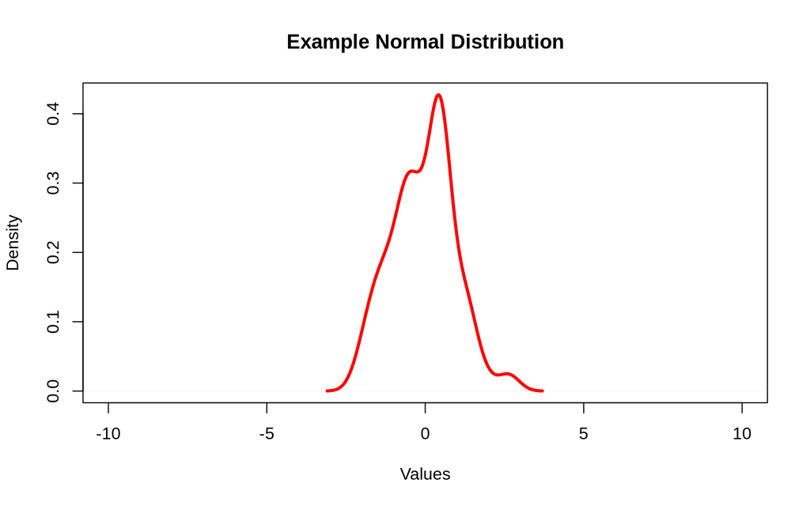

```r
x <- rnorm(n = 100, mean = 0, sd = 1)
plot(density(x), main = "Example Normal Distribution", xlab = "Values",
     xlim = c(-10, 10), lwd = 3, col = "red")
```

**Question 01**: What are the mean and standard deviation of this normal distribution?

`Q01 Answer:`

**Question 02**: What is the name of this type of normal distribution?

`Q02 Answer:`

### Exercise 01-2

`Q03 Answer:`

### Exercise 01-3

Change the standard deviation and provide the graphical output

**Question 04**: What happened to the shape of the curve?

`Q04 Answer:`

### Exercise 01-4

Change the mean and provide the graphical output

**Question 05**: What happened to the shape of the curve?

`Q05 Answer:`

## Part 02: The Z-transformation

A Z-transformation lets us use the standard normal distribution to ask questions about a population of continuous numerical observations

**Question 06**: What information do we need to know to perform a z-transformation?

`Q06 Answer:`

### Exercise 02-1

In a code chunk

1. Call the `iris` data and extract out the *Iris setosa* petal lengths
2. Assess the normality of these observations graphically

**Question 07**: Do the petal lengths pass the eyeball test?

`Q07 Answer:`

### Exercise 02-2

Assuming that all observations in the `iris` data set is representative of the entire *Iris* population for each *Iris* species, what is the population mean and standard deviation of *Iris setosa* petal lengths?

### Exercise 02-3

Let’s say that *Iris setosa* are considered more attractive to pollinators if they have petals longer than 1.6 cm. Using the Z-transformation, determine what proportion of *Iris setosa* petal lengths are wider than the 1.6 cm.

Make sure to include: 1) Hypotheses (commented) 2) All calculations 3) P-value using the `pnorm()` function. 4) Decision (commented)

**Question 08**: Given this preference by pollinators, what do you think will happen to the proportion of individuals in the`Iris setosa` population that have petals longer than 1.6 cm over time? Why?

`Q08 Answer:`